# Analisando registros de aprensões de psicoativos no Espirito Santo e o impacto do programa Estado Presente

Beatriz Lima Silveira e Esley Caminhas Ferreira

20/06/2025

# 1 Introdução

Este relatório se dedica a analisar os registros de apreensões de psicoativos no Espírito Santo, realizados por órgãos importantes da segurança pública, sendo eles: Polícia Federal, Polícia Rodoviária Federal e Polícia Estadual. Além disso, busca avaliar o impacto do programa Estado Presente, implementado pelo governo do estado em 28/12/2017.

Segundo a Secretaria de Estado de Direitos Humanos, o projeto visa à redução dos índices de criminalidade, principalmente homicídios e roubos, em regiões de maior vulnerabilidade social. As cidades de Aracruz, Guarapari, Cariacica, Colatina, Linhares, São Mateus, Serra, Vila Velha e Vitória fazem parte do Estado Presente, que é aplicado em bairros específicos desses municípios.

É importante ressaltar que o Projeto Estado Presente é implementado em bairros específicos dentro dos municípios, e não no município como um todo. Portanto, as análises apresentadas podem estar mascaradas, uma vez que agregam dados de áreas não contempladas pelo programa. Por exemplo, considerar todo o município de Vitória na análise pode diluir os efeitos observados nos bairros-alvo, como Nova Palestina.

Abaixo, apresentamos a lista dos bairros atendidos pelo programa:

- Nova Palestina, Bairro da Penha e Piedade (Vitória);
- Barramares, Ulisses Guimarães, Boa Vista (I e II), São Torquato e Santa Rita (Vila Velha);
- Feu Rosa, Vila Nova de Colares, Jardim Carapina, Novo Horizonte, Planalto Serrano, Central - Carapina e Bairro das Laranjeiras (Serra);
- Castelo Branco, Nova Rosa da Penha, Flexal II e Nova Esperança (Cariacica);
- Adalberto S. Nader e Kubitschek (Guarapari);
- Zumbi e Village da Luz (Cachoeiro de Itapemirim);
- Jacupemba (Aracruz);
- Ayrton Senna e Bela Vista (Colatina);
- Interlagos e Aviso (Linhares);
- Vila Nova e Bom Sucesso (São Mateus).

Para uma análise com rigor estatístico, foram implementados diversos métodos de visualização para dados temporalmente associados, assim como foram realizados testes estatísticos para avaliar se houve mudanças relevantes após a implementação do programa.  
Paralelamente, devido à falta de discriminação em nível de município nos registros do banco de dados disponibilizados pela Polícia Federal e pela Polícia Estadual, não foi possível avaliar o desempenho do projeto com esses dados, sendo realizada apenas uma análise geral do desempenho do Espírito Santo. Os dados disponibilizados pela Polícia Rodoviária Federal são discriminados em nível municipal, entretanto, não são discriminados em nível de bairro/distrito. Devido a esse fato, adotou-se uma abordagem generalista para representar o impacto do projeto, utilizando dados municipais.

# 2 Análise das apreensões realizadas pela Polícia Rodoviária Federal

## 2.1 Sobre os dados

Os dados são referentes as apreensões de drogas feitas pela Polícia Rodoviária Federal e foram obtidos através do Observatório Brasileiro de Informações sobre Drogas (OBID), obid/seguranca-publica, vinculado ao Ministério da Justiça e Segurança Pública.

O total são três bases relacionadas as apreensões feitas pela PF, **PRF_Apreensoes_comp**, **PRF_ApreensoesCigarro** e **PRF_ApreensoesVape**, sendo **PRF_ApreensoesCigarro** e **PRF_ApreensoesVape** bases com registro anual do total de apreensão ocorrido em cada estado. A base **PRF_ApreensoesVape** não possui nenhum registro do Espírito Santo, portanto não será abordada neste relatório. A base **PRF_ApreensoesCigarro** possui apenas registro de 2022, 2023 e 2024, suas informação são descritas abaixo:

| local_apreensao | grupo_apreensao | tipo_apreensao | unidade_apreensao | total_uf | ano | quantidade_apreensao |
| --- | --- | --- | --- | --- | --- | --- |
| ES | Diversos | Cigarros | maços | 2851907 | 2022 | 96997 |
| ES | Diversos | Cigarros | maços | 2851907 | 2023 | 1254630 |
| ES | Diversos | Cigarros | maços | 2851907 | 2024 | 1500280 |

Sendo assim, está seção será dedicada a analisar a base **PRF_Apreensoes_comp** que possui registros de data da apreensão, especificado por dia e hora. Esta base também tem variáveis descritivas que indicam se a apreensão ocorreu em zona rural ou urbana, qual o local (BR, Comercial, Residencia, etc.), qual droga foi aprendida (maconha, cocaina, etc) e é discriminada a nível municipal, tornando possível comparar os municípios com bairros onde o programa Estado Presente foi implementado.

## 2.2 Análise Descritiva

Essa seção se dedica a explorar características básicas das apreensões realizadas, principalmente em relação ao tempo e frequência de características comuns, como: “Em quais zonas há mais apreensões? Rural ou Urbana?” ou “Quão regular foram as apreensões de cannabis e derivados ao longo dos anos?”.

### 2.2.1 Total de apreensões em relação a cidades do Estado Presente

As cidades com bairros selecionados para o programa Estado Presente são: Aracruz, Cachoeiro de Itapemirim, Cariacica, Colatina, Linhares, São Mateus, Serra, Vitória, Vila Velha, Vitória. No gráfico 1, é possivel analisar a quantidade de apreensões anuais para os municípios com cidades influenciadas pelo programa Estado Presente e os demais municípios do estado.

[interactive chart not shown]

A partir de 2019, observa-se um aumento no número de apreensões nos municípios contemplados pelo programa em comparação aos demais municípios. Isso sugere que a política pública teve algum impacto na intensificação das operações da PRF nesses territórios prioritários.

### 2.2.2 Total de apreensão por mês

Avaliar o total de apreensões em um intervalo menor permite análises mais detalhadas e inferir tendências. No gráfico 3, avaliamos o total de apreensões por mês para todos os municipios do Espírito Santo.

As apreensões possuem variações mensais recorrentes, indicando possíveis padrões sazonais, como aumento nos meses de férias ou períodos de festividades. Isso pode estar relacionado a maior circulação de pessoas e veículos, e portanto, aumentando as apreensões. Ademais, é interessante realizar algum teste para confirma se há de fato sazonalidade no número de apreensões.

[interactive chart not shown]

### 2.2.3 Relação apreensão e categoria de psicoativos

Com a finalidade de avaliar a diferença em nível de apreensões para as diferentes categorias de psicoativos, foram categorizados os diferentes tipos de apreensão de drogas em grupos mais amplos e interpretáveis. Os grupos foram:

- **Cocaína e Derivados:** Cocaína/Cloridrato de Cocaína, crack;
- **Cannabis e Derivados:** Maconha, pés de Maconha, Haxixe;
- **Sintéticas/Estimulantes:** Anfetaminas, ecstasy, lança-perfume;
- **Farmacêuticos/Controlados:** Barbitúricos, medicamentos;
- **Outros:** Qualquer outro tipo não listado (ex.: LSD).

Dessa forma, no gráfico 4, é possível avaliar a quantidade e porcentagem de apreensões equivalentes de cada grupo no respectivo ano.

Ao longo dos anos, a cocaína, cannabis e seus derivados se destacam representando a grande maioria dos casos de registrados.

[interactive chart not shown]

### 2.2.4 Relação apreensão e local de ocorrência

Os locais de ocorrências registrados foram avenidas BR, ambientes comerciais, residências, serviços, veiculos, via publica e outros. Por se tratar de uma análise específica da Polícia Rodoviária Federal, a presença de apreensões em rodovias BR é esperada.

Em todos os anos analisados, a maior parte das apreensões ocorreu em rodovias BR e antes de 2020 (2017–2019), praticamente só as BRs aparecem com relevância.

A partir de 2020, percebe-se uma maior participação de outros locais, principalmente via pública. Em 2022, há o maior percentual de apreensões fora das BRs.

[interactive chart not shown]

### 2.2.5 Relação apreensão e zona de ocorrência

Nos dados disponibilizados, também é definido se a apreensão ocorreu em zona rural ou zona urbana.

Durante 2017 e 2018, as apreensões se dividem próximas a uma igualdade entre zonas rurais e urbanas, em 2019 ocorre o maior percentual de apreensões urbanas em toda a série. A partir de 2020, há uma inversão de tendência, com apreensões da área rural aumentando gradativamente.

[interactive chart not shown]

## 2.3 Relação apreensão e cidade de ocorrência

No gráfico 6, temos a distribuição percentual das apreensões realizadas pela PRF entre 2017 e 2023 nos municípios afetados pelo programa Estado Presente.É possível identificar padrões consistentes de concentração das apreensões em determinados municípios ao longo dos anos.

O município da Serra se destaca como o principal polo de apreensões na maior parte do período, liderando em anos como 2017 (51,2%), 2019 (45,2%), 2021 (35,2%) e 2022 (26,1%). Já Cariacica também apresenta forte participação, sendo responsável por mais de 30% das apreensões em 2018 (36,4%), 2019 (34,7%) e 2020 (32,7%).

Outros municípios que se mantêm entre os principais ao longo dos anos incluem Linhares e São Mateus, que, apesar de percentuais menores, contribuem com frequência significativa. Por exemplo, Linhares representou 24,4% em 2022, e São Mateus chegou a 19,5% em 2017.

Cachoeiro de Itapemirim, Vila Velha, Vitória, Aracruz e Colatina aparecem com participações mais modestas, frequentemente abaixo de 5%, sendo mais relevantes em anos pontuais — como Aracruz em 2022 (5,9%) e Colatina aparecendo com registros a partir de 2020.

Em resumo, o padrão mostra que Serra e Cariacica concentram a maior parte das apreensões, enquanto os demais municípios apresentam menor, mas recorrente, participação nas estatísticas.

[interactive chart not shown]

## 2.4 Avaliação do impacto do Programa Estado Presente

Esta seção se dedica a avaliar características da apreensões antes e depois da implementação do programa estado presente. Com o objetivo de atestar alguma tendência será aplicado o teste Mann-Kendall.

### 2.4.1 Teste de tendência

O teste de Mann-Kendall é um teste estatístico não paramétrico amplamente utilizado para detectar tendências monotônicas (crescente ou decrescente) ao longo do tempo em séries temporais. Neste relatório, iremos avaliar se o programa Estado Presente alterou de alguma forma o total de apreensões por mês, representado no gráfico 2, avaliando se há presença de alguma tendência após a aplicação do programa.

Resultados do teste de Mann-Kendall

|  | Estatística_Z | Valor_p | Tendência |
| --- | --- | --- | --- |
| z | 1.553 | 0.121 | Não significativa |

Não há evidência estatística suficiente para rejeitar a hipótese nula de ausência de tendência (ao nível de significância de 5% ou mesmo de 10%). ou seja, não podemos afirmar com confiança que o total de apreensões por mês decresceu ou aumentou nas cidades participantes do programa Estado Presente.

## 2.5 Análise espacial

Esta seção é dedicada em explorar como as apreensões se relacionam com o espaço geográfico do estado e quais áreas tiveram mais casos recorrentes de apreensão ao longo do período analisado.

Analisando o gráfico 7, percebem-se três áreas principais de aglomeração de ocorrência, região ao sul do estado, região próxima a Grande Vitória e área ao norte do estado.

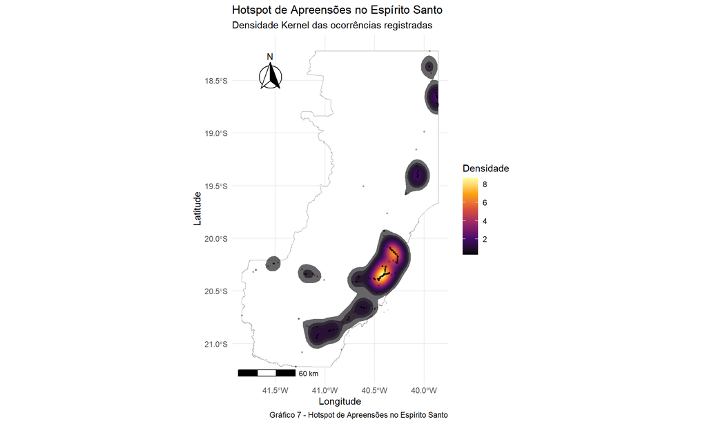

Paralelente, iremos aplicar o índice de Moran, uma medida estatística utilizada para avaliar a autocorrelação espacial, ou seja, o grau de semelhança entre valores de uma variável em localidades geograficamente próximas. Ele verifica se os valores observados em uma área estão correlacionados com os valores em áreas vizinhas — indicando se existe padrão espacial (agrupamento, dispersão ou aleatoriedade).

O índice varia entre -1 e +1:

- Moran I > 0: indica agrupamento espacial (valores semelhantes próximos uns dos outros);
- Moran I ≈ 0: indica padrão aleatório;
- Moran I < 0: indica dispersão espacial (valores opostos próximos entre si).

Ao aplicar o Índice de Moran sobre os dados de apreensões por município no Espírito Santo, conseguimos identificar se as apreensões estão distribuídas de forma aleatória no território ou se há agrupamentos geográficos significativos.

Nesta analise, o índice retornou um valor positivo e significativo, o que indica que há agrupamentos regionais de municípios com comportamentos semelhantes:

- Municípios com altas quantidades de apreensões tendem a estar próximos entre si;
- Da mesma forma, municípios com baixas quantidades também estão próximos entre si.

Resultados do Índice de Moran Global

|  | Estatística.Moran.I | Valor.Esperado | Variância | Estatística.Z | Valor.p | Significância |
| --- | --- | --- | --- | --- | --- | --- |
| Moran I statistic standard deviate | 0.21 | -0.013 | 0.0042 | 3.44 | <0.001 | Significativo |

O valor observado do Índice de Moran foi 0,21, indicando uma autocorrelação espacial positiva moderada. Isso significa que municípios com números semelhantes de apreensões (sejam eles altos ou baixos) tendem a estar geograficamente próximos, evidenciando a existência de agrupamentos espaciais.

O teste retornou um valor esperado de -0,013 (sob hipótese de aleatoriedade) e um desvio-padrão padrão de 3,44, com um valor-p associado de 0,00029. Esse resultado é altamente significativo (p < 0,001), rejeitando a hipótese nula de ausência de autocorrelação espacial. Assim, conclui-se que a distribuição das apreensões não é aleatória no espaço geográfico, e há clusters espaciais de municípios com comportamentos semelhantes em relação ao total de apreensões registradas.

# 3 Análise das apreensões realizadas pela Polícia Federal

## 3.1 Sobre os dados

Os dados são referentes às apreensões de drogas feitas pela Polícia Federal e foram obtidos através do Observatório Brasileiro de Informações sobre Drogas (OBID), obid/seguranca-publica, vinculado ao Ministério da Justiça e Segurança Pública.

Ao todo, são quatro bases relacionadas as apreensões feitas pela PF, **PF_Apreensoes_Portos_Aeroportos**, **PF_Apreensoes**, **PF_BaseCircunscricao** e **PF_NovasSubstanciasPsicoativas**.

A base **PF_BaseCircunscricao** não será utilizada na análise por se limitar a informações administrativas sobre delegacias. Da mesma forma, a base **PF_NovasSubstanciasPsicoativas** não será utilizada por não conter qualquer informação geográfica que permitisse localizar as apreensões no território nacional.

Após a filtragem por ocorrências no estado do Espírito Santo, foi verificado que a base **PF_Apreensoes_Portos_Aeroportos** se limita a somente apreensões feitas no aeroporto e porto de Vitória, já à base **PF_Apreensoes** se limita a apreensões feitas nas regiões central e litoral, noroeste e nordeste e sul do Espírito Santo.

Separação regional utilizada pela Polícia Federal na base **PF_Apreensoes**:

- **Central e litoral**: Afonso Cláudio, Alfredo Chaves, Anchieta, Aracruz, Baixo Guandu, Brejetuba, Cariacica, Colatina, Domingos Martins, Fundão, Guarapari, Ibiraçu, Itaguaçu, Itarana, João Neiva, Laranja da Terra, Linhares, Marechal Floriano, Marilândia, Rio Bananal, Santa Leopoldina, Santa Maria de Jetibá, Santa Teresa, São Roque do Canaã, Serra, Sooretama, Venda Nova do Imigrante, Viana, Vila Velha, Vitória.
- **Noroeste e Nordeste**: Água Doce do Norte, Águia Branca, Alto Rio Novo, Barra de São Francisco, Boa Esperança, Conceição da Barra, Ecoporanga, Governador Lindenberg, Jaguaré, Mantenópolis, Montanha, Mucurici, Nova Venécia, Pancas, Pedro Canário, Pinheiros, Ponto Belo, São Domingos do Norte, São Gabriel da Palha, São Mateus, Vila Pavão, Vila Valério.
- **Sul**: Alegre, Apiacá, Atilio Vivacqua, Bom Jesus do Norte, Cachoeiro de Itapemirim, Castelo, Conceição do Castelo, Divino de São Lourenço, Dores do Rio Preto, Guaçuí, Ibatiba, Ibitirama, Iconha, Irupi, Itapemirim, Iúna, Jerônimo Monteiro, Marataízes, Mimoso do Sul, Muniz Freire, Muqui, Piúma, Presidente Kennedy, Rio Novo do Sul, São José do Calçado, Vargem Alta.

## 3.2 Análise descritiva

### 3.2.1 Apreensão de drogas em portos e aeroportos pela Polícia Federal

Para o Espírito Santo, todas as apreensões foram realizadas no porto ou no aeroporto de Vitória. Observando o gráfico 8 pode-se notar que o ano de 2019 registrou o maior número de apreensões, com 13 ocorrências, das quais 11 tiveram origem no aeroporto de Vitória.

No gráfico 10 pode-se observar que o ano de 2023 registrou o maior volume em gramas apreendidas, embora tenha sido somente o terceiro em número de ocorrências segundo o gráfico 8. Observa-se ainda uma disparidade significativa entre as quantidades apreendidas de cocaína e maconha.

O Gráfico 11 apresenta o volume total de apreensões (em gramas) realizadas pela Polícia Federal em portos e aeroportos do Espírito Santo entre 2014 e 2023. Observa-se um aumento progressivo nas quantidades anuais, com crescimento contínuo a partir de 2019.

[interactive chart not shown]

### 3.2.2 Apreensões de drogas pela Polícia Federal

Substâncias derivadas da cannabis — como maconha, skunk e haxixe — foram agrupadas em uma única categoria para facilitar a visualização dos dados.

O Gráfico 12 destaca a predominância das apreensões de cannabis e seus derivados, bem como de cocaína, ao longo do período analisado. O ano de 2020 se sobressaiu, com 79 ocorrências no total, das quais 42 foram de cannabis e derivados e 11 de cocaína. Nesse mesmo ano, registrou-se também o maior número de apreensões de lança-perfume, com 11 ocorrências e um total de 460 frascos apreendidos.

O Gráfico 13 revela um aumento progressivo nas quantidades anuais apreendidas, com destaque para maconha e cocaína como as substâncias de maior volume. Em 2022, observou-se a apreensão de 3.715 kg de maconha e 1.681 kg de cocaína — os maiores volumes registrados no período.

O Gráfico 14 apresenta a distribuição das apreensões por regiões do Espírito Santo, evidenciando diferenças significativas entre os agrupamentos regionais. A Região Central e Litoral concentra a maior parte das ocorrências, um padrão consistente ao longo dos anos analisados.

Embora a ausência de detalhamento municipal impeça a associação direta com o Programa Estado Presente, é relevante destacar que essa região abrange a maioria dos municípios contemplados pela iniciativa. A concentração das apreensões nessa área pode refletir tanto a maior efetividade das ações policiais quanto as particularidades demográficas e geográficas da região.

Por fim, o Gráfico 15 apresenta o volume total de apreensões, em gramas, realizadas pela Polícia Federal no Espírito Santo entre os anos de 2014 e 2023.

[interactive chart not shown]

# 4 Análise das apreensões realizadas pelas polícias estaduais

## 4.1 Sobre os dados

Os dados são referentes às apreensões de drogas feitas pelas polícias estaduais e foram obtidos através do Observatório Brasileiro de Informações sobre Drogas (OBID), obid/seguranca-publica, vinculado ao Ministério da Justiça e Segurança Pública.

A base **SINESP_Apreensoes** contém registros mensais de apreensões de drogas realizadas pelas polícias estaduais em nível estadual.

Os dados incluem operações contra o tráfico e apreensões específicas por tipo de droga (cocaína, maconha), permitindo análises temporais e comparativas. A organização mensal facilita o acompanhamento de tendências.

Embora a base de dados contenha registros a partir de 2016, as variáveis de interesse ‘total’ e ‘peso_total’ apresentam valores exclusivamente disponíveis a partir de 2018. Os registros dos anos de 2016 e 2017 para essas métricas específicas consistem inteiramente em valores NA, indicando ausência de dados mensuráveis nesse período inicial.

## 4.2 Análise descritiva

O gráfico 16 apresenta a série temporal do peso total das apreensões de cocaína e maconha. Conforme o dicionário de dados, esta variável é definida como “valor numérico da quantidade, peso ou volume apreendido”.

Embora a unidade de medida não esteja especificada, a comparação entre os tipos de drogas permanece válida. Observa-se clara predominância da maconha (média mensal de 200.7) sobre a cocaína (média mensal de 10.5).

O gráfico 17 apresenta a série temporal do total das apreensões relacionadas a tráfico de drogas. Conforme o dicionário de dados, esta variável é definida como “valor numérico da quantidade, peso ou volume apreendido”.

[interactive chart not shown]

## 4.3 Análise temporal

A decomposição STL (Seasonal and Trend decomposition using Loess) é uma técnica estatística para analisar séries temporais, decompondo-as em três componentes principais:

- **Tendência (Trend)**: Mostra a direção geral dos dados ao longo do tempo (crescimento, declínio ou estabilidade)
- **Sazonalidade (Seasonal)**: Revela padrões que se repetem em intervalos fixos (como mensal, anual)
- **Resíduo (Remainder/Random)**: Representa variações aleatórias ou eventos não explicados

A decomposição STL adota um modelo aditivo, assumindo que a série observada é composta pela soma de suas três partes: tendência, sazonalidade e resíduo.

O teste de Mann-Kendall é uma ferramenta não paramétrica amplamente utilizada para detectar tendências monotônicas em séries temporais. Ele responde à pergunta: “Existe uma tendência crescente ou decrescente nos meus dados ao longo do tempo?”

No Gráfico 18, referente às apreensões de maconha, a decomposição sazonal revela picos recorrentes no mês de maio. No entanto, o teste de Mann-Kendall não indicou tendência significativa, sugerindo que o número de apreensões dessa substância permaneceu estável ao longo do tempo. Já no Gráfico 19, que aborda as apreensões de cocaína, observa-se sazonalidade com picos em junho e uma tendência crescente estatisticamente significativa segundo o teste de Mann-Kendall. Essa evidência também é visível na série temporal, que apresenta oscilações, mas com trajetória ascendente ao longo dos anos. Por fim, o Gráfico 20, que representa o total de apreensões, aponta picos sazonais em julho, porém, sem tendência significativa de aumento ou queda, de acordo com o teste aplicado, o que indica estabilidade no volume geral de apreensões no período analisado.

[interactive chart not shown]

# 5 Conclusão

Este relatório analisou os registros de apreensões de substâncias psicoativas no Espírito Santo realizados pela Polícia Federal, Polícia Rodoviária Federal e Polícia Estadual, com o objetivo de avaliar o impacto do programa Estado Presente implementado em 28/12/2017. Observou-se que a Polícia Federal concentrou suas maiores apreensões de cocaína em portos e aeroportos, enquanto a Polícia Federal e Estadual tiveram maior volume de apreensões de maconha em operações terrestres. Visualmente, os dados sugerem um aumento nas apreensões tanto pela Polícia Federal quanto pela Polícia Estadual.

As limitações nos dados disponíveis dificultaram uma análise mais aprofundada e conclusiva sobre a eficácia do programa. A ausência de discriminação a nível municipal nos registros da Polícia Federal e da Polícia Estadual impediu uma avaliação localizada do projeto, restringindo a análise a uma perspectiva estadual geral. Além disso, a falta de informações detalhadas antes da implementação do programa em 2017 comprometeu a comparação temporal necessária para uma conclusão robusta.

Apesar dessas limitações, os dados revelaram uma tendência de aumento nas apreensões de cocaína pela Polícia Estadual em nível estadual. Geograficamente, a maioria das apreensões concentraram-se na região Central e Litoral. Embora esses indícios sugiram uma maior efetividade na atuação policial após a implantação do Estado Presente, essa hipótese não pode ser confirmada estatisticamente devido à escassez de dados prévios e à ausência de informações mais granularizadas que permitissem isolar o efeito do programa de outras variáveis.